# 2 Python sintaksa, kontrola toka izvrsavanja

## 2.1 Podsetnik

- Problemi sa domacim?
- Pogledati **1_uvod_u_python.ipynb**

## 2.2 Promenljive

- Podsetimo se jednacina u matematici

  ```
  x + y = 7
  x - y = 1
  ```

- **x** i **y** nazivaju se *promenljivim* - to su simboli kojima mozemo dodeliti neke brojne vrednosti i time menjati njihovu vrednost
- Prethodni sistem dve jednacine sa dve nepoznate je potpun, sto znaci da postoji resenje sistema, i to takvo da su i **x** i **y** jednoznacni
- Iz prve jednacine imamo da je

  ```
  x = 7 - y
  ```

- Zamenom u drugu dobijamo

  ```
  (7 - y) - y = 1
  ===============
  7 - 2*y = 1
  ===============
  2*y = 6
  ===============
  y = 3
  ```

- Vracanjem u jednu od jednacina dobija se

  ```
  x = 4
  ```

- Dakle, **x** i **y** imaju neke svoje vrednosti koje smo nasli resavanjem jednacine
- Ideja promenljivih u matematici je da se barata apstraktnim vrednostima poput slova/simbola, sve dok ne dodje trenutak da se oni zamene za konkretne vrednosti, kada citav racun dobija neki brojni smisao
- Na slican nacin, u programskim jezicima su definisane promenljive (variables) u koje se moze smestiti neka vrednost
- Kako smo rekli, uz vrednost, promenljivoj je pripisan i **tip** koji programu govori na koji nacin da tumaci tu vrednost (kao ceo ili decimalan broj, kao niz slova...)

```python
a = 1               # Integer (celobrojni tip, koristi se za smestanje celih brojeva)
b = 3.14            # Floating point (decimalni tip, za smestanje brojeva sa zarezom)
c = "neka recenica" # String (tip za smestanje niza karaktera)
d = True            # Bool (logicka vrednost, postoji jos i False)
```

- Promenljiva zapravo predstavlja zamenu za memorijsku adresu racunara u kojoj je smestena sirova vrednost koja je dodeljena toj promenljivoj u programu
- Ovakva apstrakcija programera lisava rada sa memorijskim lokacijama
- Ime promenljive moze biti niz slova, brojeva i donjih crta, ali mora da pocne slovom
- Dobre prakse programiranja u Python-u https://www.python.org/dev/peps/pep-0008/

```python
ovo_je_ime_promenljive = 5          # Ime se sastoji od reci i underscore-ova
ovoJeImeJosJednePromenljve = "bla"  # Camel case stil
moze_daSeRad1_i_0vAKO = False       # Ali ovo je losa praksa

# Ime promenljive treba da je opisno i da nagovestava smisao te promenljive,
# sem u trivijalnim situacijama

ocena_na_faksu = 10     # Smisleno i jasno
x = 10                  # Moze da znaci bilo sta
```

### Zadatak

1. Napisati program koji dvema promenljivima zamenjuje vrednosti

```python
# Kod za prvi zadatak
a = 1
b = 3
# Neka obrada odavde



# do ovde
print(a)    # Treba da da 3
print(b)    # Treba da da 1
```

```
1
3
```

## 2.3 Rezervisane reci (keywords)

- U svakom jeziku postoje reci koje su rezervisane kako bi se obezbedio ispravan rad programa
- Ove reci kompajler/interpreter tumaci kao specijalne instrukcije
- Nijedan korisnicki identifikator (za ime promenljive, funkcije, klase) ne sme koristiti ove reci
- Spisak https://docs.python.org/3/reference/lexical_analysis.html#keywords

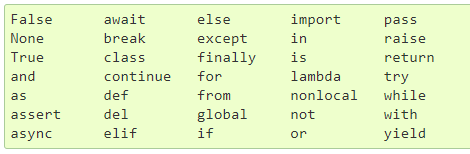

```python
# Radno vreme
from = 8    # Ne sme! Python prepoznaje 'from' kao kljucnu rec
to = 16     # U redu

# S druge strane, ovo je ok
fromTime = 8
toTime = 16
print_moj_broj()    # Poziv funkcije koja nosi ovo ime
```

```
  File "<ipython-input-2-b7508ff6126a>", line 2
    from = 8    # Ne sme! Python prepoznaje 'from' kao kljucnu rec
         ^
SyntaxError: invalid syntax
```

## 2.4 Velika i mala slova

- Python je case-sensitive - pravi razliku izmedju malih i velikih slova

### Zadatak

1. Napisati program koji sa standardnog ulaza ucitava IME KORISNIKA (uneto svim velikim slovima) i ime korisnika (uneto svim malim) i smestiti ih u zasebne promenljive. Uporediti ove dve promenljive operatorom

   ```
   prom1 == prom2
   ```

```python
# Napomena: operator == poredi dva izraza i vraca True ako su oni jednaki, u suprotnom False
1 == 2
```

```
False
```

```python
# Kod za prvi zadatak
```

## 2.5 Razliciti nacini koriscenja funkcije print, f-string

- Kako smo videli, **print** je izuzetno fleksibilna funkcija za ispis na standardni izlaz (ekran)

```python
# Mozemo odmah vrednost da ispisemo
print(5)

# Kao i rezultat neke operacije
print(1 + 5)

# Stringove takodje
print("Ovo je string")

# Dodatno, print moze primiti i vise argumenata svih gorenavedenih varijanti odvojenih zarezima
print("Rodjen sam pre", 2020 - 1996, "godine")
```

```
5
6
Ovo je string
Rodjen sam pre 24 godine
```

- Jedan koristan nacin da se u stringove ubaci vrednost neke promenljive je koriscenjem tzv. *f-string*-ova
- Ovo je najnoviji nacin, koriscen od Python-a 3.6.5 naovamo i drzacemo se njega

```python
promenljiva = 5

s = f"Ovde cemo ubaciti vrednost {promenljiva}"

print(s)
```

```
Ovde cemo ubaciti vrednost 5
```

- Ovo je jako zgodan feature koji ce vam zasigurno trebati, recimo

```python
ime = "Josip Broz"
dugo = 27
zanimanje = "Masinbravar"

tito = f"{zanimanje} {ime} je bio predsednik Jugoslavije {dugo} godina"

print(tito)
```

```
Masinbravar Josip Broz je bio predsednik Jugoslavije 27 godina
```

## 2.6 Tipovi podataka

- Objasnili smo da tip koji je pridruzen promenljivoj sluzi programu da rastumaci na koji nacin da barata promenljivom (int, float, string, bool...)
- Ispod je data tabela sa ovim, tzv. *primitivnim* tipovima

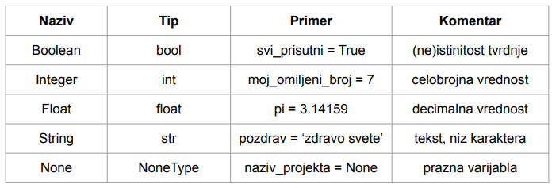

- Tip nekog podatka moguce je proveriti koriscenjem ugradjene funkcije *type*

```python
print(type("neki tekst"))
print(type(4))
print(type(3.141592))
print(type(True))

nista = None
print(type(nista))   # Specijalan tip
```

```
<class 'str'>
<class 'int'>
<class 'float'>
<class 'bool'>
<class 'NoneType'>
```

- Jedan tip je moguce prevesti u drugi (ako to jezik dozvoljava, jer ne mozete recenicu, recimo, prevesti u ceo broj smisleno) koriscenjem *kastovanja* (cast)

```python
print(int(3.1415))  # Prevesce ga u ceo broj cime ce otfikariti deo iza zareza
print(float(10))    # U sustini ce dodati decimalni zarez na kraj broja (i nule iza njega)
print(float("5.5")) # I ovo je ok, ali je ovo bas nastimano da radi
print(int("Ovo vec nece moci jer nema smisla"))
```

```
3
10.0
5.5
```

```
---------------------------------------------------------------------------
ValueError                                Traceback (most recent call last)
<ipython-input-15-5a21dde09fae> in <module>()
      2 print(float(10))    # U sustini ce dodati decimalni zarez na kraj broja (i nule iza njega)
      3 print(float("5.5")) # I ovo je ok, ali je ovo bas nastimano da radi
----> 4 print(int("Ovo vec nece moci jer nema smisla"))

ValueError: invalid literal for int() with base 10: 'Ovo vec nece moci jer nema smisla'
```

### Zadatak

1. Oprobati sva moguca kastovanja izmedju primitivnih tipova

```python
# Kod za zadatak 1
```

## 2.7 Aritmeticke operacije

- Prioritet isti kao u matematici:
  > - Zagrade ()
  > - Eksponent **
  > - Mnozenje *, deljenje /, celobrojno deljenje //, ostatak %
  > - Sabiranje +, oduzimanje -
- Najpametnije je koristiti zagrade kako se ne bi neocekivane stvari dogadjale

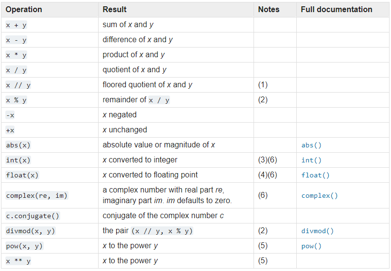

### Zadatak

1. Oprobati razne aritmeticke operacije
2. Naci ceo deo i ostatak pri deljenju 4 sa 3

## 2.8 Operatori poredjenja

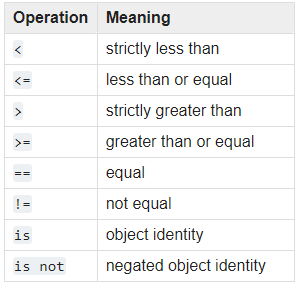

### Zadatak

1. Oprobati operatore poredjenja nad razlicitim primitivnim tipovima

## 2.9 Logicki operatori

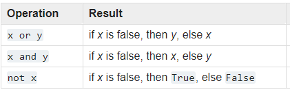

### Zadatak

1. Oprobati logicke operatore nad Bool tipovima

## 2.10 Kontrola toka

- Kod se obicno izvrsava sekvencijalno - liniju po liniju
- Cesto se desava da je potrebna neka uslovna obrada - u slucaju da **x**, uradi **y**, u suprotnom **z**
- Ovo se postize **if**, **else** i **elif** naredbama

```python
broj = 5

if broj % 2 == 0:
    print("broj je paran")
else:
    print("broj je neparan")
```

```
broj je neparan
```

### Zadatak

1. Za uneti broj sa standardnog ulaza odrediti u kom opsegu se nalazi - [0, 100], (100, 200] ili (200, 300]

## 2.11 Indentacija

- Python ne koristi { } kao sto to radi vecina jezika kako bi grupisao blokove naredbi
- U Pythonu se to postize indentacijom redova, sto programera tera da pise lep i uredan kod

```python
if 1 > 2:
    # Ovaj blok naredbi je uvucen i sve one ce
    # se desiti ako je prvi if tacan
    print("Prvi if je tacan")
    a = 1 + 3
# Medjutim ovaj sledeci blok nije uvucen, te ne spada
# pod blok ispod if-a
print("Ovo ce se svakako desiti")
```

```
Ovo ce se svakako desiti
```

- U drugim C-based jezicima ovo izgleda ovako

```
if (1 > 2) {
    print(...);
    a = 1 + 3;
}

print(...);
```

- Takodje, nigde se ne koristi ; za cim ni nema potrebe ako je sve uredno pisano

## 2.12 Domaci

1. Napisati program koji pomaze kasirki da vrati kusur kupcu. Za unetu cenu artikla, kolicinu i iznos koji je kupac dao, program treba da ispise vrednost kusura. Sve ulazne vrednosti su pozitivni celi brojevi. Pretpostaviti da je unos ispravan.

```
# Primer

Unesite cenu, kolicinu i iznos:
==============================
# Korisnikov unos
150, 3, 500
==============================
# Izlaz programa
Kusur je 50 dinara
```

1. Napisati program koji za slovima uneti dan u nedelji ispisuje redni broj tog dana u sedmici

```
# Primer

Unesite dan u nedelji:
===============================
# Korisnikov unos
Cetvrtak
===============================
# Izlaz programa
4
```

1. Napisati program koji za unetu godinu i mesec ispisuje naziv meseca kao i koliko dana taj mesec ima te godine. U slucaju neispravnog unosa, ispisati odgovarajucu poruku o gresci. Obratiti paznju na prestupne godine. https://sr.wikipedia.org/sr-ec/%D0%9F%D1%80%D0%B5%D1%81%D1%82%D1%83%D0%BF%D0%BD%D0%B0_%D0%B3%D0%BE%D0%B4%D0%B8%D0%BD%D0%B0

```
# Primer 1
Unesite godinu:
===================
2018
===================
Unesite mesec:
===================
13
===================
# Izlaz
Neispravan unos meseca!

========================

# Primer 2
Unesite godinu:
==================
2000
==================
Unesite mesec:
==================
2
==================
# Izlaz
Februar, 29 dana
```

1. Napisati program koji za uneti pozitivan trocifren broj ispisuje njegove cifre, jedinica, desetica i stotina. Pretpostaviti da je unos ispravan.

```
# Primer

Unesite trocifren broj:
=======================
123
=======================
# Izlaz
Jedinice: 3
Desetice: 2
Stotine: 1
```

1. Napisati program koji za uneti pozitivan cetvorocifren broj ispisuje njegovu najvecu cifru. Voditi racuna da unos bude ispravan. Ako nije, ispisati gresku.

```
# Primer

Unesite cetvorocifren broj:
==========================
6585
==========================
# Izlaz
Najveca cifra je 8
```